#### Raport zaliczeniowy z przedmiotu

# Zaawansowane modelowanie symulacyjne

#### sygnatura przedmiotu: 234060-S

# Modelowanie kosztu transportu na przykładzie własnego samochodu, carsharingu i Ubera (Python)

##### Autorzy raportu:

Yana Korin - nr albumu 77939

Patryk Kwiatkowski - nr albumu 77581

Jan Masny - nr albumu 107503

# Spis treści

- Podsumowanie
- Opis problemu
- Model symulacji
- Analiza główna
- Analiza wrażliwości
  - Zadanie 1
  - Zadanie 2
  - Zadanie 3
  - Zadanie 4
  - Zadanie 5
- Wnioski i rekomendacje
- Bibliogriafia

# Podsumowanie

Głównym zadaniem analizy było ustalenie najlepszego kosztowo rozwiązania pod kątem dojazdów do pracy przez Pana Piotra Nowaka. Analiza obejmowała porównanie kosztów posiadania i użytkowania własnego samochodu, korzystania z car sharingu oraz z Ubera. Dodatkowe punkty, przedstawione w poniższej analizie wrażliwości obejmują następujące pytania:

- Które rozwiązanie jest najlepsze w zależności od liczby przejechanych kilometrów dziennie? (analiza 1 parametru)
- Które rozwiązania jest najlepsze w zależności do horyzontu czasowego? (analiza 1 parametru)
- Jak na łączny koszt eksploatacji własnego samochodu osobowego wpływa parametr początkowej utraty wartości samochodu po wyjechaniu z salonu, współczynnik starzenia się samochodu oraz koszt zakupu samochodu? (analiza 3 parametrów)
- Jak okres używania samochodu wpływa na powyższy łączny koszt eksploatacji samochodu? (analiza 4 parametów)
- Jaki wpływ na rozwiązanie optymalne ma wysokość opłaty dziennej za abonament oraz limit kilometrów dostępnych w abonamencie w carsharingu względem kosztu wynajmu Ubera? (analiza 2 parametrów)

Do przeprowadzenia powyżej analizy został stworzony model symulacyjny wyliczający koszty korzystania z każdego rozwiązania. Zmienne użyte do modelowania są przestawione poniżej. </div>

#### Zmienne globalne:

- horyzont czasowy
- liczba iteracji
- liczba przejechanych kilometów dziennie

#### Zmienne opisujące koszystanie z własnego samochódu:

- koszt zakupu samochodu
- spadek ceny samochodu
- spalanie paliwa
- cena paliwa
- ubezpieczenie samochodu
- koszt naprawy samochodu
- spadek wartości samochodu
- grzywna za parkowanie bez pozwolenia

#### Zmienne opisujące korzystanie z carsharingu:

- abonament car sharingu
- limit km w ramach abonamentu
- koszt za km
- dodatkowa opłata poza abonamentem
- koszt wypadku

#### Zmienne opisujące koszystanie z Ubera:

- liczba przypadków korzystania z Ubera
- koszt za trzasnięcie drzwiami
- koszt za kilometr

# Opis problemu

Pan Piotr Nowak postanowił ostatnio przyjął ofertę nowej pracy. W związku z powyższym, będzie potrzebował samochodu na codzienne dojazdy do biura. Pan Piotr rozważa trzy opcje do rozwiązania danego problemu. Pierwszy pomysł dotyczy kupna samochodu, co będzie się wiązało z większymi kosztami na start (Pana Piotra interesuje tylko nowy samochód), ale Piotr ma nadzieję, że w długim okresie to rozwiązanie okaże się tańsze.

Kolejną opcją, którą zaproponował mu znajomy, to korzystanie z wypożyczalni samochodów. Według jego kolegi nie trzeba się przejmować tankowaniem, ubezpieczeniem i co najważniejsze - nie trzeba mieć dużych środków na zakup pojazdu. Niemniej jednak niesie to za sobą pewne niebezpieczeństwo związane z spowodowaniem kolizji, ponieważ wiadomo, że takie wypadki mogą być bardzo kosztowne.

Wracając późno z imprezy Pan Piotr wynajął Ubera i był bardzo zadowolony z przejazdu. Zamówienie usługi było bardzo wygodne, szybkie i relatywnie niedrogie, a sam koszt przejazdu znał już przed zamówieniem samochodu. Uznał, że to może być kolejne rozwiązanie jego problemu, tylko czy ta opcja w długim okresie nie będzie zbyt droga?

Żeby rozwiązać swój problem Pan Piotr postanowił stworzyć model do symulacji kosztów korzystania z każdego rozwiązania.

```python
import numpy as np
import pandas as pd
import scipy as sc
import matplotlib.pyplot as plt
import seaborn as sns
import math
from matplotlib.pyplot import figure
import statistics
plt.style.use('seaborn-whitegrid')
```

##### Przypisanie odpowiednich początkowych wartości parametrom modelu

```python
# global
time_horizon = 90             # w dniach
km_day       = 50             # w kilometrach na dzien
iterations   = 10             # liczba przeprowadzonych iteracji


# own_car
car_cost              = 80000 # koszt zakupu samochodu w zlotowkach
price_drop            = 15    # spadek ceny "po wyjechaniu z salonu"
car_fuel_consumption  = 9     # spalanie wlasnego samochodu na 100 km
fuel_price            = 5.0   # cena paliwa
oc_ac                 = 1000  # koszt ubezpieczenia rocznie
repair_var            = 0.05  # koszt naprawy liczony wyrazony w procencie wartosci samochodu
age_parameter         = 0.001 # spadek wartosci samochodu per dzien
mu_parameter          = 48    # do rozkladu poissona
fine                  = 5000  # grzywna za parkowanie bez znacznika na parkingu firmy


# carsharing
km_limit_month = 300          # limit km na miesiac w abonamencie
cs_day_cost    = 40           # koszt zakupu abonamentu per dzien
km_cost        = 1            # koszt za km w carsharingu
penalty        = 3            # wspolczynik dodatkowej oplaty za km poza abonamentem (> 1)
crash                 = 5000  # koszt wypadku w carsharingu

# uber
uber_rides = 5                # ile razy zamówiony został uber
uber_init  = 10               # opłata początkowa
uber_km    = 1.8              # koszt km za kilometr (wliczony jest koszt związany z czasem przejazdu)
```

# Model symulacyji

```python
def model(time_horizon, km_day, car_cost, price_drop, car_fuel_consumption, fuel_price, oc_ac, repair_var, age_parameter, mu_parameter, fine, km_limit_month, cs_day_cost, km_cost, penalty, crash, uber_rides, uber_init, uber_km):

    own_car = 0
    carsharing = 0
    uber = 0

    # liczba przejechanym km w calym modelowanym okresie dla wlasnego samochodu i carsharingu
    total_km = km_day * time_horizon

    # own_car - wlasny samochod

    # zwiekszenie kosztu o zakup samochodu
    own_car += car_cost
    # zapamietanie poczatkowej wartosci samochodu
    car_value = car_cost
    # spadek wartosci samochodu po wyjechaniu z salonu
    car_value = car_value * ((100 - price_drop) / 100)

    for day in range(1, time_horizon + 1):
        # zwiekszenie kosztu o koszt zwiazany z liczba przejechanych km dziennie
        own_car += (km_day * car_fuel_consumption / 100) * fuel_price
        # zmniejszenie wartosci samochodu w zwiazku z rosnacym przebiegiem i wiekiem
        car_value -= car_value * age_parameter + km_day * (age_parameter / 10)
        if (day % 365 == 0):
            fuel_price *= 1.015

    # liczba miesiecy w okresie modelowanym
    month_no = math.ceil(time_horizon / 365 * 12)
    # zmienna odpowiadajaca za prawdopodobienstwo awarii
    a = 1
    # zmienna zwiekszajaca prawdopodobienstwo kazdej kolejnej awarii
    j = 1
    # koszt ewentualnych napraw samochodu - rozpatrujemy prawdopodobienstwo awarii raz w kazdym miesiacu
    for months in range(month_no):
        # prawdopodobienstwo awarii dane jest rozkladem poissona
        accident_probability = sc.stats.poisson.cdf(a*j, mu_parameter)
        if accident_probability > np.random.sample():
            # zwiekszenie kosztu, jesli nastapila awaria
            own_car += car_cost * repair_var
            a = 0
            j += 1
        a += 1

    # liczba szans, w ktorych mogla nastapic grzywna
    fine_chance = fine // 1000
    for k in range(fine_chance):
        # jesli zdarzy sie kontrola to grzywna nastepuje z 10% prawdopodobienstwem
        if np.random.sample() > 0.9:
            # zwiekszenie kosztu samochodu o koszt zwiazany z grzywna
            own_car += fine

    # dodanie kosztu ubezpieczenia w calym modelowanym okresie
    own_car = own_car + (time_horizon // 365 + 1) * oc_ac
    # finalny koszt posiadania wlasnego samochodu pomniejszony o aktualna wartosc samochodu
    own_car = own_car - car_value


    # carsharing

    # dzien danego miesiaca
    day_no = 0

    for day in range(1, time_horizon + 1):

        # obliczenie dnia miesiaca oraz numeru danego miesiaca (zakładamy 30 dniowy miesiac)
        day_no += 1
        single_month_number = day_no / 30
        # wyzerowanie licznika dni po uplynieciu jednego miesiaca
        if single_month_number > 1:
            day_no = 0

        if km_day * day_no <= km_limit_month:
            # zwiekszenie kosztu korzystania z carsharingu od przejechanych km i oplaty abonamentowej
            carsharing += km_day * km_cost + cs_day_cost
        else:
            # zwiekszenie kosztu korzystania z carsharingu od przejechanych km i oplaty abonamentowej z dodatkowym uwzglednieniem kary za przekroczenie limitu dostepnych km
            carsharing += km_day * km_cost * penalty + cs_day_cost

    crash_chance = total_km // 1000
    for i in range(crash_chance):
        # wypadek nastepuje z 10% prawdopodobienstwem
        if np.random.sample() > 0.9:
            # zwiekszenie kosztu carsharingu o koszt zwiazany z wypadkiem
            carsharing += crash

    # uber

    # koszt korzystania z ubera
    uber = (uber_rides * uber_init + uber_km * km_day) * time_horizon

    # wyniki
    own_car = round(own_car, 2)
    carsharing = round(carsharing, 2)
    uber = round(uber, 2)

    return [own_car, carsharing, uber]
```

```python
def run_model(iterations, time_horizon, km_day, car_cost, price_drop, car_fuel_consumption, fuel_price, oc_ac, repair_var, age_parameter, mu_parameter, fine, km_limit_month, cs_day_cost, km_cost, penalty, crash, uber_rides, uber_init, uber_km):
    m1 = []
    m2 = []
    m3 = []
    for i in range(1, iterations + 1):
        np.random.seed(i)
        tmp = model(time_horizon, km_day, car_cost, price_drop, car_fuel_consumption, fuel_price, oc_ac, repair_var, age_parameter, mu_parameter, fine, km_limit_month, cs_day_cost, km_cost, penalty, crash, uber_rides, uber_init, uber_km)
        m1.append(tmp[0])
        m2.append(tmp[1])
        m3.append(tmp[2])

  # m1 - lista wartosci dla samochodu
  # m2 - lista wartosci dla carsharingu
  # m3 - lista wartosci dla ubera
  # zwracana jest lista, skladajaca sie z 3 list
    return [m1, m2, m3]
```

# Analiza główna

Dla domyślnych wartości, które na początku założył Pan Piotr wyniki prezentują się następująco:

```python
first = run_model(iterations, time_horizon, km_day, car_cost, price_drop, car_fuel_consumption, fuel_price, oc_ac, repair_var, age_parameter, mu_parameter, fine, km_limit_month, cs_day_cost, km_cost, penalty, crash, uber_rides, uber_init, uber_km)
print('Koszt korzystania z własnego samochodu:', np.mean(first[0]), '[odchylenie standardowe:', round(np.std(first[0]),2), ']')
print('Koszt korzystania z carsharingu:', np.mean(first[1]), '[odchylenie standardowe:', np.std(first[1]), ']')
print('Koszt korzystania z ubera:', np.mean(first[2]), '[odchylenie standardowe:', np.std(first[2]), ']')
```

```
Koszt korzystania z własnego samochodu: 22380.91 [odchylenie standardowe: 2291.29 ]
Koszt korzystania z carsharingu: 15600.0 [odchylenie standardowe: 1500.0 ]
Koszt korzystania z ubera: 12600.0 [odchylenie standardowe: 0.0 ]
```

Pan Piotr zdecydował się zatem przeprowadzić analizę wrażliwości dla najważniejszych parametrów modelu, tak aby znaleźć odpowiedzi na nurtujące go pytania.

# Analiza wrażliwości

### Które rozwiązanie jest najlepsze w zależności od liczby przejechanych kilometrów dziennie? (analiza 1 parametru)

```python
# Zmiana parametru km_day

results_ownc = []
results_shar = []
results_uber = []
param_km_day = []
dataframe_output = []

for km_day in range (1, 201, 10):
    results = run_model(iterations, time_horizon, km_day, car_cost, price_drop, car_fuel_consumption, fuel_price, oc_ac, repair_var, age_parameter, mu_parameter, fine, km_limit_month, cs_day_cost, km_cost, penalty, crash, uber_rides, uber_init, uber_km)

    results_ownc = (statistics.mean(results[0]))
    results_shar = (statistics.mean(results[1]))
    results_uber = (statistics.mean(results[2]))
    param_km_day = km_day

    dataframe_output.append([results_ownc, results_shar, results_uber,
                                param_km_day])
```

```python
km_simulation_df = pd.DataFrame(dataframe_output, columns = ["Own_Car", "Car_Sharing", "Uber",
                                                             "KM"]).round(4)

print(km_simulation_df)
```

```
     Own_Car  Car_Sharing     Uber   KM
0   20395.99         3690   4662.0    1
1   20801.07         4744   6282.0   11
2   21206.16         7422   7902.0   21
3   21611.24        10172   9522.0   31
4   22016.33        12784  11142.0   41
5   22421.42        16136  12762.0   51
6   22826.50        19362  14382.0   61
7   23231.59        22282  16002.0   71
8   23636.68        25188  17622.0   81
9   24041.76        28668  19242.0   91
10  24446.85        31754  20862.0  101
11  24851.93        34294  22482.0  111
12  25257.02        37334  24102.0  121
13  25662.11        40874  25722.0  131
14  26067.19        43914  27342.0  141
15  26472.28        47360  28962.0  151
16  26877.36        51960  30582.0  161
17  27282.45        54560  32202.0  171
18  27687.54        57160  33822.0  181
19  28092.62        60760  35442.0  191
```

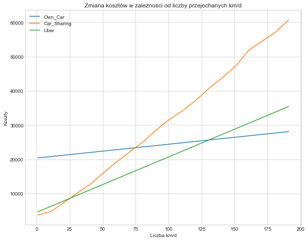

```python
plt.figure(figsize=(10, 8))

ax = plt.gca()

km_simulation_df.plot(kind='line',x='KM',y='Own_Car', ax=ax)
km_simulation_df.plot(kind='line',x='KM',y='Car_Sharing', ax=ax)
km_simulation_df.plot(kind='line',x='KM',y='Uber', ax=ax)

plt.ylabel('Koszty')
plt.xlabel('Liczba km/d')
plt.title('Zmiana kosztów w zależności od liczby przejechanych km/d')
plt.show()
```

### Które rozwiązania jest najlepsze w zależności do horyzontu czasowego? (analiza 1 parametru)

```python
# Zmiana parametru time_horizon

results_ownc2 = []
results_shar2 = []
results_uber2 = []
param_time_horizon = []
results_ownc_std2 = []
dataframe_output2 = []


for time_horizon1 in range (1, 101, 1):
    results2 = run_model(iterations, time_horizon1, km_day, car_cost, price_drop, car_fuel_consumption, fuel_price, oc_ac, repair_var, age_parameter, mu_parameter, fine, km_limit_month, cs_day_cost, km_cost, penalty, crash, uber_rides, uber_init, uber_km)

    results_ownc2 = (statistics.mean(results2[0]))
    results_shar2 = (statistics.mean(results2[1]))
    results_uber2 = (statistics.mean(results2[2]))

    param_time_horizon = time_horizon1

    dataframe_output2.append([results_ownc2, results_shar2, results_uber2,
                                    param_time_horizon])
```

```python
time_simulation_df = pd.DataFrame(dataframe_output2, columns = ["Own_Car", "Car_Sharing", "Uber",
                                                             "Time"]).round(4)

print(time_simulation_df)
```

```
     Own_Car  Car_Sharing     Uber  Time
0   15153.97          231    393.8     1
1   15307.87          844    787.6     2
2   15461.70         1457   1181.4     3
3   15615.47         2070   1575.2     4
4   15769.17         2683   1969.0     5
..       ...          ...      ...   ...
95  28480.36        64174  37804.8    96
96  28628.10        64787  38198.6    97
97  28775.78        65400  38592.4    98
98  28923.40        66013  38986.2    99
99  29070.95        67626  39380.0   100

[100 rows x 4 columns]
```

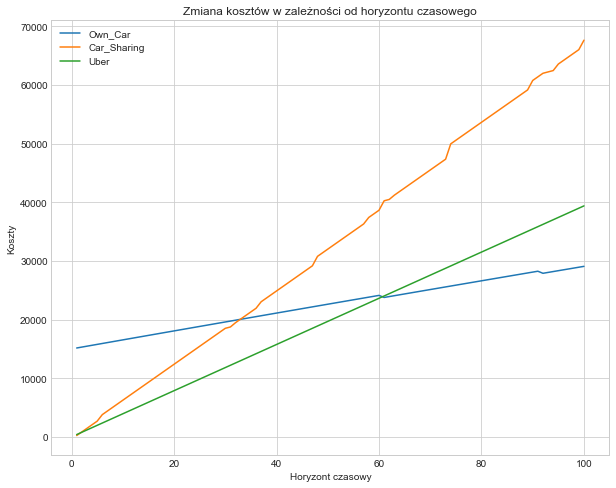

```python
plt.figure(figsize=(10, 8))

ax = plt.gca()

time_simulation_df.plot(kind='line',x='Time',y='Own_Car', ax=ax)
time_simulation_df.plot(kind='line',x='Time',y='Car_Sharing', ax=ax)
time_simulation_df.plot(kind='line',x='Time',y='Uber', ax=ax)

plt.ylabel('Koszty')
plt.xlabel('Horyzont czasowy')
plt.title('Zmiana kosztów w zależności od horyzontu czasowego')
plt.show()
```

##### Interpretacja wyników

Wyniki są zgdone z intuicją. Z wykresu można odcztytać, że koszty rosną wraz ze zwiększeniem horyzontu czasowego, lecz w różnym stopniu dla każdego rozwiązania.

### Jak na łączny koszt eksploatacji własnego samochodu osobowego wpływa parametr początkowej utraty wartości samochodu po wyjechaniu z salonu, współczynnik starzenia się samochodu oraz koszt zakupu samochodu? (analiza 3 parametrów)

##### Przywrócenie parametrów do wartości początkowych

```python
# global
time_horizon = 90
km_day       = 50
iterations   = 10


# own_car
car_cost              = 80000
price_drop            = 15
car_fuel_consumption  = 9
fuel_price            = 5.0
oc_ac                 = 1000
repair_var            = 0.05
age_parameter         = 0.001
mu_parameter          = 48
fine                  = 5000

# carsharing
km_limit_month = 300
cs_day_cost    = 40
km_cost        = 1
penalty        = 3
crash          = 5000

# uber
uber_rides = 5
uber_init  = 10
uber_km    = 1.8
```

```python
time_horizon = 90

range_of_cars_cost = range(20 * 1000, 80 * 1001, 10 * 1000)    # Zakres wartosci dla car_cost
range_of_price_drop = range(15, 41, 5)                         # Zakres wartosci dla price_drop
range_of_age_parameter = np.arange(0.0001, 0.01001, 0.0001)    # Zakres wartosci dla age_parameter

results_ownc = []
results_shar = []
results_uber = []
parameter_car_cost = []
parameter_age_para = []
dataframe_output = []


for age_parameter in range_of_age_parameter:
    for car_cost in range_of_cars_cost:
        results = run_model(iterations, time_horizon, km_day, car_cost, price_drop, car_fuel_consumption, fuel_price, oc_ac, repair_var, age_parameter, mu_parameter, fine, km_limit_month, cs_day_cost, km_cost, penalty, crash, uber_rides, uber_init, uber_km)

        results_ownc = (statistics.mean(results[0]))
        results_shar = (statistics.mean(results[1]))
        results_uber = (statistics.mean(results[2]))

        parameter_car_cost = car_cost
        parameter_age_para = age_parameter

        dataframe_output.append([results_ownc, results_shar, results_uber,
                                parameter_car_cost, parameter_age_para])
```

##### Stworzenie tabeli z uzyskanymi wartościami

```python
car_simulation_df = pd.DataFrame(dataframe_output, columns = ["Own_Car", "Car_Sharing", "Uber",
                                                             "Car_Cost", "Age_Parameter"])

car_simulation_df.sample(10).sort_index()
```

|  | Own_Car | Car_Sharing | Uber | Car_Cost | Age_Parameter |
| --- | --- | --- | --- | --- | --- |
| 92 | 12046.40 | 15600 | 12600.0 | 30000 | 0.0014 |
| 223 | 33566.00 | 15600 | 12600.0 | 80000 | 0.0032 |
| 341 | 36286.40 | 15600 | 12600.0 | 70000 | 0.0049 |
| 441 | 14988.45 | 15600 | 12600.0 | 20000 | 0.0064 |
| 449 | 20348.12 | 15600 | 12600.0 | 30000 | 0.0065 |
| 456 | 20476.02 | 15600 | 12600.0 | 30000 | 0.0066 |
| 486 | 31942.28 | 15600 | 12600.0 | 50000 | 0.0070 |
| 537 | 44852.82 | 15600 | 12600.0 | 70000 | 0.0077 |
| 579 | 46425.13 | 15600 | 12600.0 | 70000 | 0.0083 |
| 598 | 34993.70 | 15600 | 12600.0 | 50000 | 0.0086 |

##### Heatmapa

Heatmapa pokazująca wpływ parametru szybkości utraty wartości samochodu i kosztu zakupu samochodu na łączny koszt eksploatacji własnego samochodu osobowego.

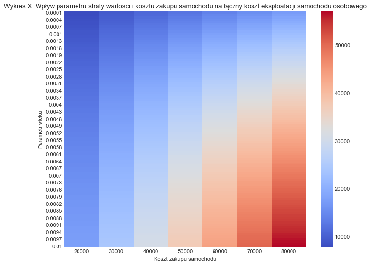

```python
car_simulation_crosstab = pd.crosstab(index   = round(car_simulation_df['Age_Parameter'], 5),
                                      columns = car_simulation_df['Car_Cost'],
                                      values  = car_simulation_df['Own_Car'],
                                      aggfunc = np.sum)

figure(figsize = (10, 8), dpi = 80)
wykres_heat_car_simulation = sns.heatmap(car_simulation_crosstab,
                                         annot = False,
                                         linewidths = 0,
                                         cmap = "coolwarm")
title = "Wykres X. Wpływ parametru straty wartosci i kosztu zakupu samochodu na łączny koszt eksploatacji samochodu osobowego"
plt.ylabel('Parametr wieku')
plt.xlabel('Koszt zakupu samochodu')
plt.title(title, loc = 'center')

plt.show()
```

##### Wykres 3D

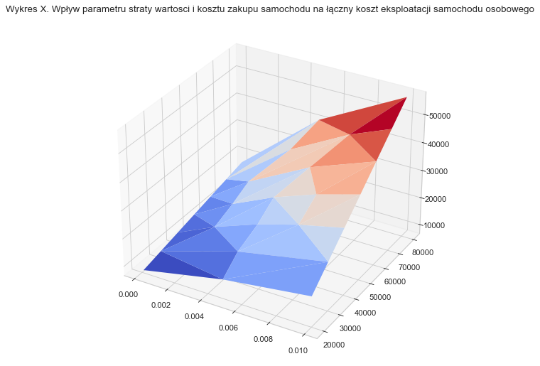

```python
figure(figsize = (10, 8), dpi = 80)
ax = plt.axes(projection = '3d')
ax.plot_trisurf(car_simulation_df['Age_Parameter'],
                car_simulation_df['Car_Cost'],
                car_simulation_df['Own_Car'],
                cmap = 'coolwarm',
                edgecolor = 'none')
ax.set_title("Wykres X. Wpływ parametru straty wartosci i kosztu zakupu samochodu na łączny koszt eksploatacji samochodu osobowego")
plt.show()
```

##### Interpretacja wyników

Punkt pierwszy analizy wrażliwości polegał na zbadaniu zmiany finalnego kosztu użytkowania samochodu osobowego w zależności od ceny auta oraz szybkości utraty samochodu wraz z jego starzeniem się. W tym celu stworzona została heatmapa oraz wykres 3D. Pod uwagę został wzięty koszt samochodu w przedziale od 20 000 do 80 000 zmieniający się co 10 000 oraz parametr wieku z przedziału od 0.0001 do 0.01 zmieniający się co 0.0001. Interpretacja parametru wieku jest bardzo prosta - jest to wartość, o którą wartość samochodu zmniejsza się z każdym kolejnym dniem. Uzyskany wynik jest zgodny z intuicją - wraz z wzrostem kosztu zakupu samochodu oraz z coraz większym parametrem wieku koszty eksploatacji samochodu rosną (do maksimum wynoszącego 57 006 zł przy najwyższym koszcie samochodu równym 80 000 zł oraz najwyższym parametrze wieku wynoszącym 1%). Najbardziej optymistyczny scenariusz znajdował się na drugim biegunie - koszt użytkowania samochodu przez okres 3 miesięcy przy aucie kosztującym początkowo 20 000 zł oraz parametrze wieku wynoszącym 0.01% wyniosł zaledwie 7 677 zł.

### Jak okres używania samochodu wpływa na powyższy łączny koszt eksploatacji samochodu? (analiza 4 parametów)

Jaki efekt na finalny koszt eksploatacji samochodu będą miały cena samochodu, wysokość straty wartości "po wyjechaniu z salonu" oraz parametr utraty wartości samochodu? W analizie weźmiemy pod uwagę krótki i długi horyzont symulacji aby być gotowym na każdy scenariusz. Pomoże to Panu Piotrowi w decyzji czy opłaca mu się ponosić ryzyko inwestycji w własny samochód, nawet jeżeli ten będzie używany jedynie przez krótki okres.

##### Studium przypadku - krótki okres

Piotr podpisał trzy miesięczną umowę na okres próbny, po której zdecyduje dopiero czy przedłuży kontrakt i zostanie w pracy. Jeżeli nie zdecyduje się na taki krok, samochód nie będzie eksploatowany w takim samym stopniu po upływie 3 miesięcy. W tej części przyjrzymy się o ile spadnie wartość samochodu Pawła, jeżeli ten będzie go użytkował tylko przez 3 miesiące.

```python
time_horizon = 90

range_of_cars_cost = range(20 * 1000, 80 * 1001, 10 * 1000) # Zakres wartosci dla car_cost
range_of_price_drop = range(10, 41, 5)                      # Zakres wartosci dla price_drop
range_of_age_parameter = np.arange(0.0001, 0.01001, 0.0001) # Zakres wartosci dla age_parameter

results_ownc         = []
results_shar         = []
results_uber         = []
parameter_car_cost   = []
parameter_age_para   = []
parameter_price_drop = []
dataframe_output     = []

for price_drop in range_of_price_drop:
    for age_parameter in range_of_age_parameter:
        for car_cost in range_of_cars_cost:
            results = run_model(iterations, time_horizon, km_day, car_cost, price_drop, car_fuel_consumption, fuel_price, oc_ac, repair_var, age_parameter, mu_parameter, fine, km_limit_month, cs_day_cost, km_cost, penalty, crash, uber_rides, uber_init, uber_km)

            results_ownc = (statistics.mean(results[0]))
            results_shar = (statistics.mean(results[1]))
            results_uber = (statistics.mean(results[2]))

            parameter_car_cost   = car_cost
            parameter_age_para   = age_parameter
            parameter_price_drop = price_drop

            dataframe_output.append([results_ownc, results_shar, results_uber,
                                    parameter_car_cost, parameter_age_para, parameter_price_drop])
```

##### Stworzenie tabeli z danymi

```python
car_simulation_df = pd.DataFrame(dataframe_output, columns = ["Own_Car", "Car_Sharing", "Uber",
                                                             "Car_Cost", "Age_Parameter", "Price_Drop"])

car_simulation_df.sample(10).sort_index()
```

|  | Own_Car | Car_Sharing | Uber | Car_Cost | Age_Parameter | Price_Drop |
| --- | --- | --- | --- | --- | --- | --- |
| 88 | 16491.61 | 15600 | 12600.0 | 60000 | 0.0013 | 10 |
| 647 | 35118.66 | 15600 | 12600.0 | 50000 | 0.0093 | 10 |
| 1053 | 27701.97 | 15600 | 12600.0 | 50000 | 0.0051 | 15 |
| 1156 | 20476.02 | 15600 | 12600.0 | 30000 | 0.0066 | 15 |
| 1877 | 21657.29 | 15600 | 12600.0 | 30000 | 0.0069 | 20 |
| 2066 | 24454.69 | 15600 | 12600.0 | 30000 | 0.0096 | 20 |
| 2067 | 31096.95 | 15600 | 12600.0 | 40000 | 0.0096 | 20 |
| 2145 | 19315.70 | 15600 | 12600.0 | 50000 | 0.0007 | 25 |
| 3648 | 18532.18 | 15600 | 12600.0 | 30000 | 0.0022 | 35 |
| 3931 | 42244.13 | 15600 | 12600.0 | 60000 | 0.0062 | 35 |

##### Tabele z porównaniem kosztów w zależności od wartości ww. parametrów

```python
pd.set_option('display.max_rows', None)

groups_list = ['Car_Cost', 'Age_Parameter', 'Price_Drop']
groupped_df   = car_simulation_df.groupby(groups_list).apply(lambda a: a[:])
groupped_df_2 = groupped_df.sort_values('Own_Car')
groupped_df_3 = groupped_df_2.drop(['Car_Sharing', 'Uber', 'Car_Cost', 'Age_Parameter', 'Price_Drop'], axis = 1)
```

Koszty korzystania z carsharingu oraz Ubera:

```python
print("""Koszt Carsharingu przez okres {} dni: {} zł
Koszt Ubera       przez okres {} dni: {} zł""".format(time_horizon, car_simulation_df.iloc[2, 1].round(0), time_horizon, car_simulation_df.iloc[3, 2].round(0)))
```

```
Koszt Carsharingu przez okres 90 dni: 15600 zł
Koszt Ubera       przez okres 90 dni: 12600.0 zł
```

Najbardziej optymistyczne scenariusze

```python
groupped_df_3.head(20)
```

| Car_Cost | Age_Parameter | Price_Drop |  | Own_Car |
| --- | --- | --- | --- | --- |
| 20000 | 0.0001 | 10 | 0 | 6686.33 |
|  | 0.0002 | 10 | 7 | 6846.22 |
|  | 0.0003 | 10 | 14 | 7004.70 |
|  | 0.0004 | 10 | 21 | 7161.78 |
|  | 0.0005 | 10 | 28 | 7317.46 |
|  | 0.0006 | 10 | 35 | 7471.76 |
|  | 0.0007 | 10 | 42 | 7624.70 |
|  | 0.0001 | 15 | 700 | 7677.37 |
| 30000 | 0.0001 | 10 | 1 | 7766.97 |
| 20000 | 0.0008 | 10 | 49 | 7776.27 |
|  | 0.0002 | 15 | 707 | 7828.38 |
|  | 0.0009 | 10 | 56 | 7926.51 |
|  | 0.0003 | 15 | 714 | 7978.06 |
| 30000 | 0.0002 | 10 | 8 | 8006.79 |
| 20000 | 0.0010 | 10 | 63 | 8075.41 |
|  | 0.0004 | 15 | 721 | 8126.41 |
|  | 0.0011 | 10 | 70 | 8222.99 |
| 30000 | 0.0003 | 10 | 15 | 8244.49 |
| 20000 | 0.0005 | 15 | 728 | 8273.45 |
|  | 0.0012 | 10 | 77 | 8369.26 |

Najbardziej kosztowne scenariusze

```python
groupped_df_3.tail(20)
```

| Car_Cost | Age_Parameter | Price_Drop |  | Own_Car |
| --- | --- | --- | --- | --- |
| 80000 | 0.0095 | 35 | 4164 | 62503.36 |
|  | 0.0087 | 40 | 4808 | 62665.17 |
|  | 0.0096 | 35 | 4171 | 62702.60 |
|  | 0.0088 | 40 | 4815 | 62862.80 |
|  | 0.0097 | 35 | 4178 | 62900.06 |
|  | 0.0089 | 40 | 4822 | 63058.65 |
|  | 0.0098 | 35 | 4185 | 63095.76 |
|  | 0.0090 | 40 | 4829 | 63252.76 |
|  | 0.0099 | 35 | 4192 | 63289.70 |
|  | 0.0091 | 40 | 4836 | 63445.12 |
|  | 0.0100 | 35 | 4199 | 63481.91 |
|  | 0.0092 | 40 | 4843 | 63635.77 |
|  | 0.0093 | 40 | 4850 | 63824.72 |
|  | 0.0094 | 40 | 4857 | 64011.97 |
|  | 0.0095 | 40 | 4864 | 64197.55 |
|  | 0.0096 | 40 | 4871 | 64381.47 |
|  | 0.0097 | 40 | 4878 | 64563.75 |
|  | 0.0098 | 40 | 4885 | 64744.39 |
|  | 0.0099 | 40 | 4892 | 64923.42 |
|  | 0.0100 | 40 | 4899 | 65100.84 |

##### Studium przypadku - długi okres

Jeżeli Piotr zdecyduje się przedłużyć umowę w nowym miejscu pracy auto będzie mu potrzebne przez zdecydowanie dłużej. W poniższej symulacji zobaczymy o ile zmieni się wartość samochodu przy założeniu, że Piotr będzie korzystał z auta przez najbliższe 2 lata

```python
# Liczy się około 3min
time_horizon = 365 * 2

range_of_cars_cost = range(20 * 1000, 80 * 1001, 10 * 1000) # Zakres wartosci dla car_cost
range_of_price_drop = range(10, 41, 5)                      # Zakres wartosci dla price_drop
range_of_age_parameter = np.arange(0.0001, 0.01001, 0.0001) # Zakres wartosci dla age_parameter

#Puste listy
results_ownc         = []
results_shar         = []
results_uber         = []
parameter_car_cost   = []
parameter_age_para   = []
parameter_price_drop = []
dataframe_output     = []

for price_drop in range_of_price_drop:
    for age_parameter in range_of_age_parameter:
        for car_cost in range_of_cars_cost:
            results = run_model(iterations, time_horizon, km_day, car_cost, price_drop, car_fuel_consumption, fuel_price, oc_ac, repair_var, age_parameter, mu_parameter, fine, km_limit_month, cs_day_cost, km_cost, penalty, crash, uber_rides, uber_init, uber_km)

            results_ownc = (statistics.mean(results[0]))
            results_shar = (statistics.mean(results[1]))
            results_uber = (statistics.mean(results[2]))

            parameter_car_cost   = car_cost
            parameter_age_para   = age_parameter
            parameter_price_drop = price_drop

            dataframe_output.append([results_ownc, results_shar, results_uber,
                                    parameter_car_cost, parameter_age_para, parameter_price_drop])
```

##### Stworzenie tabeli z danymi

```python
car_simulation_df = pd.DataFrame(dataframe_output, columns = ["Own_Car", "Car_Sharing", "Uber",
                                                             "Car_Cost", "Age_Parameter", "Price_Drop"])

car_simulation_df.sample(10).sort_index()
```

|  | Own_Car | Car_Sharing | Uber | Car_Cost | Age_Parameter | Price_Drop |
| --- | --- | --- | --- | --- | --- | --- |
| 1302 | 42524.33 | 141500 | 102200.0 | 20000 | 0.0087 | 15 |
| 1578 | 66572.52 | 141500 | 102200.0 | 50000 | 0.0026 | 20 |
| 1840 | 101918.48 | 141500 | 102200.0 | 80000 | 0.0063 | 20 |
| 1846 | 92037.15 | 141500 | 102200.0 | 70000 | 0.0064 | 20 |
| 2281 | 93582.55 | 141500 | 102200.0 | 80000 | 0.0026 | 25 |
| 3239 | 92067.23 | 141500 | 102200.0 | 70000 | 0.0063 | 30 |
| 3689 | 40873.74 | 141500 | 102200.0 | 20000 | 0.0028 | 35 |
| 3937 | 72230.85 | 141500 | 102200.0 | 50000 | 0.0063 | 35 |
| 4133 | 72512.10 | 141500 | 102200.0 | 50000 | 0.0091 | 35 |
| 4407 | 78536.87 | 141500 | 102200.0 | 60000 | 0.0030 | 40 |

```python
pd.set_option('display.max_rows', None)

groups_list = ['Car_Cost', 'Age_Parameter', 'Price_Drop']
groupped_df   = car_simulation_df.groupby(groups_list).apply(lambda a: a[:])
groupped_df_2 = groupped_df.sort_values('Own_Car')
groupped_df_3 = groupped_df_2.drop(['Car_Sharing', 'Uber', 'Car_Cost', 'Age_Parameter', 'Price_Drop'], axis = 1)
```

Koszty korzystania z carsharingu oraz Ubera:

```python
print("""Koszt Carsharingu przez okres {} dni: {} zł
Koszt Ubera       przez okres {} dni: {} zł""".format(time_horizon, car_simulation_df.iloc[2, 1].round(0), time_horizon, car_simulation_df.iloc[3, 2].round(0)))
```

```
Koszt Carsharingu przez okres 730 dni: 141500 zł
Koszt Ubera       przez okres 730 dni: 102200.0 zł
```

Najbardziej optymistyczne scenariusze

```python
groupped_df_3.head(20)
```

| Car_Cost | Age_Parameter | Price_Drop |  | Own_Car |
| --- | --- | --- | --- | --- |
| 20000 | 0.0001 | 10 | 0 | 25815.79 |
|  |  | 15 | 700 | 26745.38 |
|  | 0.0002 | 10 | 7 | 26994.26 |
| 30000 | 0.0001 | 10 | 1 | 27449.41 |
| 20000 | 0.0001 | 20 | 1400 | 27674.98 |
|  | 0.0002 | 15 | 707 | 27858.40 |
|  | 0.0003 | 10 | 14 | 28089.86 |
|  | 0.0001 | 25 | 2100 | 28604.58 |
|  | 0.0002 | 20 | 1407 | 28722.55 |
| 30000 | 0.0001 | 15 | 701 | 28843.80 |
| 20000 | 0.0003 | 15 | 714 | 28893.15 |
| 40000 | 0.0001 | 10 | 2 | 29083.03 |
| 20000 | 0.0004 | 10 | 21 | 29108.41 |
| 30000 | 0.0002 | 10 | 8 | 29216.95 |
| 20000 | 0.0001 | 30 | 2800 | 29534.18 |
|  | 0.0002 | 25 | 2107 | 29586.69 |
|  | 0.0003 | 20 | 1414 | 29696.45 |
|  | 0.0004 | 15 | 721 | 29855.13 |
|  | 0.0005 | 10 | 28 | 30055.32 |
| 30000 | 0.0001 | 20 | 1401 | 30238.20 |

Najbardziej kosztowne scenariusze

```python
groupped_df_3.tail(20)
```

| Car_Cost | Age_Parameter | Price_Drop |  | Own_Car |
| --- | --- | --- | --- | --- |
| 80000 | 0.0096 | 35 | 4171 | 102507.71 |
|  | 0.0098 | 25 | 2785 | 102507.91 |
|  | 0.0095 | 40 | 4864 | 102508.00 |
|  | 0.0099 | 20 | 2092 | 102508.32 |
|  | 0.0100 | 15 | 1399 | 102508.90 |
|  | 0.0098 | 30 | 3485 | 102510.92 |
|  | 0.0097 | 35 | 4178 | 102510.94 |
|  | 0.0099 | 25 | 2792 | 102511.12 |
|  | 0.0096 | 40 | 4871 | 102511.21 |
|  | 0.0100 | 20 | 2099 | 102511.51 |
|  | 0.0099 | 30 | 3492 | 102513.93 |
|  | 0.0098 | 35 | 4185 | 102513.94 |
|  | 0.0100 | 25 | 2799 | 102514.11 |
|  | 0.0097 | 40 | 4878 | 102514.19 |
|  | 0.0100 | 30 | 3499 | 102516.72 |
|  | 0.0099 | 35 | 4192 | 102516.73 |
|  | 0.0098 | 40 | 4885 | 102516.96 |
|  | 0.0100 | 35 | 4199 | 102519.32 |
|  | 0.0099 | 40 | 4892 | 102519.54 |
|  | 0.0100 | 40 | 4899 | 102521.93 |

##### Interpretacja wyników

W drugim punkcie analizy wrażliwości dodatkowo został uwzględniony koszt ponoszony przez kupującego po wyjeździe autem z salonu (zmienna price_drop). Jest to natychmiastowa utrata wartości samochodu po zakupie i zmianie statusu auta z "nowego" na "używany". Parametr ten przyjmował wartości od 10% do 40% zmieniając się co 5 punktów procentowych. Oprócz uwzględnienia powyższego parametru okres modelowany został rozdzielony na dwa różne podokresy - krótki okres wynoszący 3 miesiące oraz długi okres wynoszący 2 lata.

Krótki okres

Najbardziej optymistyczny scenariusz okazał się być analogiczny jak w punkcie poprzednim - koszt użytkowania samochodu wyniósł zaledwie 6 686 zł przy koszcie zakupu auta równym 20 000 zł, parametrze wieku 0.01% oraz spadku ceny po kupnie o 10%. Najgorszy scenariusz przewidywał już wydatek rzędu 65 100 zł przy najwyższych możliwych parametrach.

### Jaki wpływ na rozwiązanie optymalne ma wysokość opłaty dziennej za abonament oraz limit kilometrów dostępnych w abonamencie w carsharingu względem Ubera? (analiza 2 parametrów)

Pan Piotr zdecydował, że nie chce posiadać własnego samochodu, ponieważ czerpie on niesamowitą przyjemność z jazdy różnymi modelami samochodów. Zarówno korzystanie z carsharingu jak i ubera zapewnia mu taką możliwość. Zatem Pan Piotr chciałby zorientować się, z którego środka lokomocji powinien korzystać, aby nie przepłacać. Operator samochodów na wynajem uwzględnia następujące opłaty:

- wysokość dziennej opłaty za abonament
- limit kilometrów dostępnych w cenie abonamentu
- opłata za przejechany kilometr
- dodatkowa opłata związana z przekroczeniem limitu kilometrów wykupionych w ramach abonamentu
- opłata za spowodowanie wypadku

W usłudze typu Uber wyróżnia się:

- opłatę początkową
- opłatę za przejechany kilometr (w której uwzględniona jest również opłata za czas przejazdu)

Rozpatrzmy zatem sytuację, w której:

W takim wypadku przy jakiej wysokości stawki opłaty dziennej za abonament w carsharingu oraz przy jakiej wysokości limitu dostępnych kilometrów w ramach abonamentu Panu Piotrowi opłacałoby się korzystać z carsharingu, a kiedy z Ubera?

##### Przywrócenie parametrów do wartości początkowych

```python
# global
time_horizon = 90
km_day       = 50
iterations   = 10


# own_car
car_cost              = 80000
price_drop            = 15
car_fuel_consumption  = 9
fuel_price            = 5.0
oc_ac                 = 1000
repair_var            = 0.05
age_parameter         = 0.001
mu_parameter          = 48
fine                  = 5000

# carsharing
km_limit_month = 300
cs_day_cost    = 40
km_cost        = 1
penalty        = 3
crash          = 5000

# uber
uber_rides = 5
uber_init  = 10
uber_km    = 1.8
```

##### Ustawienie parametrów branych pod uwagę w analizie

```python
time_horizon = 90
km_day = 25

# Stale wartosci dla carsharingu
km_cost = 0.7
penalty = 3
crash = 5000

# Stale wartosci dla Ubera
uber_rides = 3
uber_init = 10
uber_km = 1.8

# Zmienne dla carsharingu
range_of_km_limit_month = range(100, 401, 10)
range_of_cs_day_cost = range(10, 41, 1)

cs_uber = []

for x in range_of_km_limit_month:
    for y in range_of_cs_day_cost:
        results = run_model(iterations, time_horizon, km_day, car_cost, price_drop, car_fuel_consumption, fuel_price, oc_ac, repair_var, age_parameter, mu_parameter, fine, x, y, km_cost, penalty, crash, uber_rides, uber_init, uber_km)
        cs_uber.append([x, y, np.mean(results[1]), np.std(results[1]), np.mean(results[2]), np.std(results[2])])
```

##### Wyniki symulacji

```python
cs_uber_df = pd.DataFrame(cs_uber, columns = ["Abonament km limit", "Abonament day cost", "Carsharing cost", "CS cost std", "Uber cost", "Uber cost std"])
cs_uber_df.head(10)
```

|  | Abonament km limit | Abonament day cost | Carsharing cost | CS cost std | Uber cost | Uber cost std |
| --- | --- | --- | --- | --- | --- | --- |
| 0 | 100 | 10 | 5135.0 | 0.0 | 6750.0 | 0.0 |
| 1 | 100 | 11 | 5225.0 | 0.0 | 6750.0 | 0.0 |
| 2 | 100 | 12 | 5315.0 | 0.0 | 6750.0 | 0.0 |
| 3 | 100 | 13 | 5405.0 | 0.0 | 6750.0 | 0.0 |
| 4 | 100 | 14 | 5495.0 | 0.0 | 6750.0 | 0.0 |
| 5 | 100 | 15 | 5585.0 | 0.0 | 6750.0 | 0.0 |
| 6 | 100 | 16 | 5675.0 | 0.0 | 6750.0 | 0.0 |
| 7 | 100 | 17 | 5765.0 | 0.0 | 6750.0 | 0.0 |
| 8 | 100 | 18 | 5855.0 | 0.0 | 6750.0 | 0.0 |
| 9 | 100 | 19 | 5945.0 | 0.0 | 6750.0 | 0.0 |

```python
# obliczenie roznicy oplaty za carsharing wzgledem ubera
cs_uber_df['Difference'] = cs_uber_df['Carsharing cost'] - cs_uber_df['Uber cost']
cs_uber_df.head(10)
```

|  | Abonament km limit | Abonament day cost | Carsharing cost | CS cost std | Uber cost | Uber cost std | Difference |
| --- | --- | --- | --- | --- | --- | --- | --- |
| 0 | 100 | 10 | 5135.0 | 0.0 | 6750.0 | 0.0 | -1615.0 |
| 1 | 100 | 11 | 5225.0 | 0.0 | 6750.0 | 0.0 | -1525.0 |
| 2 | 100 | 12 | 5315.0 | 0.0 | 6750.0 | 0.0 | -1435.0 |
| 3 | 100 | 13 | 5405.0 | 0.0 | 6750.0 | 0.0 | -1345.0 |
| 4 | 100 | 14 | 5495.0 | 0.0 | 6750.0 | 0.0 | -1255.0 |
| 5 | 100 | 15 | 5585.0 | 0.0 | 6750.0 | 0.0 | -1165.0 |
| 6 | 100 | 16 | 5675.0 | 0.0 | 6750.0 | 0.0 | -1075.0 |
| 7 | 100 | 17 | 5765.0 | 0.0 | 6750.0 | 0.0 | -985.0 |
| 8 | 100 | 18 | 5855.0 | 0.0 | 6750.0 | 0.0 | -895.0 |
| 9 | 100 | 19 | 5945.0 | 0.0 | 6750.0 | 0.0 | -805.0 |

##### Wybranie kombinacji zawierających potencjalne rozwiązanie optymalne

```python
cs_zoom = cs_uber_df.loc[(cs_uber_df['Difference'] >= -3000) & (cs_uber_df['Difference'] <= 3000)]
cs_zoom.head(10)
```

|  | Abonament km limit | Abonament day cost | Carsharing cost | CS cost std | Uber cost | Uber cost std | Difference |
| --- | --- | --- | --- | --- | --- | --- | --- |
| 0 | 100 | 10 | 5135.0 | 0.0 | 6750.0 | 0.0 | -1615.0 |
| 1 | 100 | 11 | 5225.0 | 0.0 | 6750.0 | 0.0 | -1525.0 |
| 2 | 100 | 12 | 5315.0 | 0.0 | 6750.0 | 0.0 | -1435.0 |
| 3 | 100 | 13 | 5405.0 | 0.0 | 6750.0 | 0.0 | -1345.0 |
| 4 | 100 | 14 | 5495.0 | 0.0 | 6750.0 | 0.0 | -1255.0 |
| 5 | 100 | 15 | 5585.0 | 0.0 | 6750.0 | 0.0 | -1165.0 |
| 6 | 100 | 16 | 5675.0 | 0.0 | 6750.0 | 0.0 | -1075.0 |
| 7 | 100 | 17 | 5765.0 | 0.0 | 6750.0 | 0.0 | -985.0 |
| 8 | 100 | 18 | 5855.0 | 0.0 | 6750.0 | 0.0 | -895.0 |
| 9 | 100 | 19 | 5945.0 | 0.0 | 6750.0 | 0.0 | -805.0 |

##### Graficzna prezentacja wyników analizy

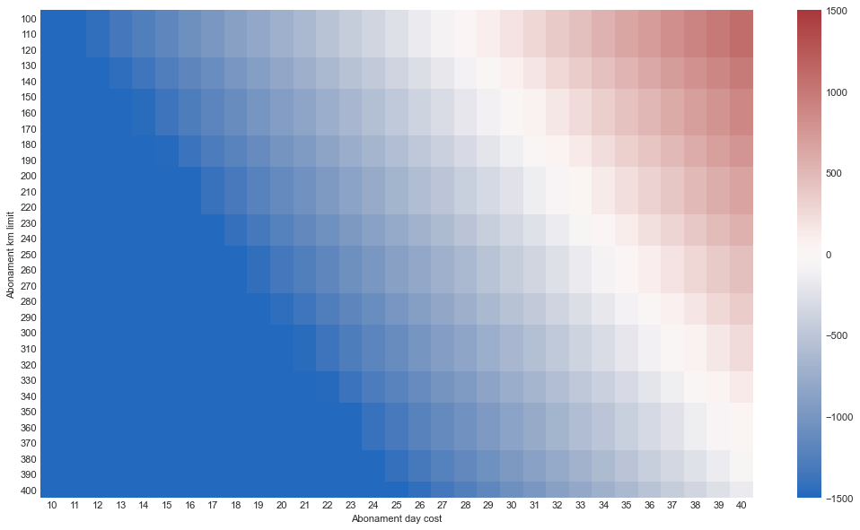

```python
cs_crosstab_zoom = pd.crosstab(index   = cs_zoom['Abonament km limit'],
                                      columns = cs_zoom['Abonament day cost'],
                                      values  = cs_zoom['Difference'],
                                      aggfunc = np.sum)

figure(figsize = (16, 9), dpi = 80)
cs_heatmap = sns.heatmap(cs_crosstab_zoom,
                                         annot = False,
                                         linewidths = 0,
                                         cmap = "vlag",
                                         vmin = -1500,
                                         vmax = 1500)
plt.show()
```

##### Stworzenie tabeli zawierającej wartości znajdujące się w okolicy progu opłacalności

```python
cs_edge = cs_uber_df.loc[(cs_uber_df['Abonament day cost'] >= 15) & (cs_uber_df['Abonament day cost'] <= 37)]
cs_edge.head(10)
```

|  | Abonament km limit | Abonament day cost | Carsharing cost | CS cost std | Uber cost | Uber cost std | Difference |
| --- | --- | --- | --- | --- | --- | --- | --- |
| 5 | 100 | 15 | 5585.0 | 0.0 | 6750.0 | 0.0 | -1165.0 |
| 6 | 100 | 16 | 5675.0 | 0.0 | 6750.0 | 0.0 | -1075.0 |
| 7 | 100 | 17 | 5765.0 | 0.0 | 6750.0 | 0.0 | -985.0 |
| 8 | 100 | 18 | 5855.0 | 0.0 | 6750.0 | 0.0 | -895.0 |
| 9 | 100 | 19 | 5945.0 | 0.0 | 6750.0 | 0.0 | -805.0 |
| 10 | 100 | 20 | 6035.0 | 0.0 | 6750.0 | 0.0 | -715.0 |
| 11 | 100 | 21 | 6125.0 | 0.0 | 6750.0 | 0.0 | -625.0 |
| 12 | 100 | 22 | 6215.0 | 0.0 | 6750.0 | 0.0 | -535.0 |
| 13 | 100 | 23 | 6305.0 | 0.0 | 6750.0 | 0.0 | -445.0 |
| 14 | 100 | 24 | 6395.0 | 0.0 | 6750.0 | 0.0 | -355.0 |

```python
cs_list = ['Abonament km limit', 'Abonament day cost']
cs_gr_df   = cs_edge.groupby(cs_list).apply(lambda a: a[:])
cs_gr_df_2 = cs_gr_df.drop(['Abonament day cost', 'Abonament km limit'], axis = 1)
cs_gr_df_2.head(10)
```

| Abonament km limit | Abonament day cost |  | Carsharing cost | CS cost std | Uber cost | Uber cost std | Difference |
| --- | --- | --- | --- | --- | --- | --- | --- |
| 100 | 15 | 5 | 5585.0 | 0.0 | 6750.0 | 0.0 | -1165.0 |
|  | 16 | 6 | 5675.0 | 0.0 | 6750.0 | 0.0 | -1075.0 |
|  | 17 | 7 | 5765.0 | 0.0 | 6750.0 | 0.0 | -985.0 |
|  | 18 | 8 | 5855.0 | 0.0 | 6750.0 | 0.0 | -895.0 |
|  | 19 | 9 | 5945.0 | 0.0 | 6750.0 | 0.0 | -805.0 |
|  | 20 | 10 | 6035.0 | 0.0 | 6750.0 | 0.0 | -715.0 |
|  | 21 | 11 | 6125.0 | 0.0 | 6750.0 | 0.0 | -625.0 |
|  | 22 | 12 | 6215.0 | 0.0 | 6750.0 | 0.0 | -535.0 |
|  | 23 | 13 | 6305.0 | 0.0 | 6750.0 | 0.0 | -445.0 |
|  | 24 | 14 | 6395.0 | 0.0 | 6750.0 | 0.0 | -355.0 |

##### Interpretacja wyników

Opisywaną analizę wrażliwości rozpoczęto od zdefiniowania kilku założeń, a następnie przypisano im stałe wartości. W kolejnym kroku stworzone zostały wartości dla zmiennych będącymi parametrami w danej analizie. Dla zmiennej opisującej limit kilometrów w ramach abonamentu carsharingowego stworzono listę wartości od 100 do 400 z krokiem co 10. W przypadku dziennego kosztu opłaty za abonament rozpatrzono wartości od 10 do 40 z krokiem co 1.

Wyniki przeprowadzonej analizy odzwierciedla heatmapa, która obrazuje wartość różnicy w kosztach osiąganych dla obu strategii (różnica jest liczona względem kosztu carsharingu tzn. im mniejsza jest wartość różnicy tym bardziej opłacalny jest carsharing) w zależności od wartości limitu kilometrów dostępnych w ramach abonamentu oraz od wysokości opłaty dziennej za abonament. Ponadto stworzono tabelę, z której można odczytać dokładne wartości dotyczące kosztów w zależności od wartości rozpatrywanych parametrów. Końcowa tabela zawiera wyłącznie wartości bliskie wartości progowej, tak aby zwiększyć czytelność wyników.

Z tabeli końcowej można odczytać dokładne wartości opłat, dla których dane rozwiązanie jest bardziej opłacalne względem drugiego. Dla przykładu wybrano wartość limitu kilometrów w abonamencie wynoszące 180km oraz 330 km.

```python
cs_gr_df_2.iloc[184:207,:]
```

| Abonament km limit | Abonament day cost |  | Carsharing cost | CS cost std | Uber cost | Uber cost std | Difference |
| --- | --- | --- | --- | --- | --- | --- | --- |
| 180 | 15 | 253 | 5270.0 | 0.0 | 6750.0 | 0.0 | -1480.0 |
|  | 16 | 254 | 5360.0 | 0.0 | 6750.0 | 0.0 | -1390.0 |
|  | 17 | 255 | 5450.0 | 0.0 | 6750.0 | 0.0 | -1300.0 |
|  | 18 | 256 | 5540.0 | 0.0 | 6750.0 | 0.0 | -1210.0 |
|  | 19 | 257 | 5630.0 | 0.0 | 6750.0 | 0.0 | -1120.0 |
|  | 20 | 258 | 5720.0 | 0.0 | 6750.0 | 0.0 | -1030.0 |
|  | 21 | 259 | 5810.0 | 0.0 | 6750.0 | 0.0 | -940.0 |
|  | 22 | 260 | 5900.0 | 0.0 | 6750.0 | 0.0 | -850.0 |
|  | 23 | 261 | 5990.0 | 0.0 | 6750.0 | 0.0 | -760.0 |
|  | 24 | 262 | 6080.0 | 0.0 | 6750.0 | 0.0 | -670.0 |
|  | 25 | 263 | 6170.0 | 0.0 | 6750.0 | 0.0 | -580.0 |
|  | 26 | 264 | 6260.0 | 0.0 | 6750.0 | 0.0 | -490.0 |
|  | 27 | 265 | 6350.0 | 0.0 | 6750.0 | 0.0 | -400.0 |
|  | 28 | 266 | 6440.0 | 0.0 | 6750.0 | 0.0 | -310.0 |
|  | 29 | 267 | 6530.0 | 0.0 | 6750.0 | 0.0 | -220.0 |
|  | 30 | 268 | 6620.0 | 0.0 | 6750.0 | 0.0 | -130.0 |
|  | 31 | 269 | 6710.0 | 0.0 | 6750.0 | 0.0 | -40.0 |
|  | 32 | 270 | 6800.0 | 0.0 | 6750.0 | 0.0 | 50.0 |
|  | 33 | 271 | 6890.0 | 0.0 | 6750.0 | 0.0 | 140.0 |
|  | 34 | 272 | 6980.0 | 0.0 | 6750.0 | 0.0 | 230.0 |
|  | 35 | 273 | 7070.0 | 0.0 | 6750.0 | 0.0 | 320.0 |
|  | 36 | 274 | 7160.0 | 0.0 | 6750.0 | 0.0 | 410.0 |
|  | 37 | 275 | 7250.0 | 0.0 | 6750.0 | 0.0 | 500.0 |

```python
cs_gr_df_2.iloc[529:552,:]
```

| Abonament km limit | Abonament day cost |  | Carsharing cost | CS cost std | Uber cost | Uber cost std | Difference |
| --- | --- | --- | --- | --- | --- | --- | --- |
| 330 | 15 | 718 | 4640.0 | 0.0 | 6750.0 | 0.0 | -2110.0 |
|  | 16 | 719 | 4730.0 | 0.0 | 6750.0 | 0.0 | -2020.0 |
|  | 17 | 720 | 4820.0 | 0.0 | 6750.0 | 0.0 | -1930.0 |
|  | 18 | 721 | 4910.0 | 0.0 | 6750.0 | 0.0 | -1840.0 |
|  | 19 | 722 | 5000.0 | 0.0 | 6750.0 | 0.0 | -1750.0 |
|  | 20 | 723 | 5090.0 | 0.0 | 6750.0 | 0.0 | -1660.0 |
|  | 21 | 724 | 5180.0 | 0.0 | 6750.0 | 0.0 | -1570.0 |
|  | 22 | 725 | 5270.0 | 0.0 | 6750.0 | 0.0 | -1480.0 |
|  | 23 | 726 | 5360.0 | 0.0 | 6750.0 | 0.0 | -1390.0 |
|  | 24 | 727 | 5450.0 | 0.0 | 6750.0 | 0.0 | -1300.0 |
|  | 25 | 728 | 5540.0 | 0.0 | 6750.0 | 0.0 | -1210.0 |
|  | 26 | 729 | 5630.0 | 0.0 | 6750.0 | 0.0 | -1120.0 |
|  | 27 | 730 | 5720.0 | 0.0 | 6750.0 | 0.0 | -1030.0 |
|  | 28 | 731 | 5810.0 | 0.0 | 6750.0 | 0.0 | -940.0 |
|  | 29 | 732 | 5900.0 | 0.0 | 6750.0 | 0.0 | -850.0 |
|  | 30 | 733 | 5990.0 | 0.0 | 6750.0 | 0.0 | -760.0 |
|  | 31 | 734 | 6080.0 | 0.0 | 6750.0 | 0.0 | -670.0 |
|  | 32 | 735 | 6170.0 | 0.0 | 6750.0 | 0.0 | -580.0 |
|  | 33 | 736 | 6260.0 | 0.0 | 6750.0 | 0.0 | -490.0 |
|  | 34 | 737 | 6350.0 | 0.0 | 6750.0 | 0.0 | -400.0 |
|  | 35 | 738 | 6440.0 | 0.0 | 6750.0 | 0.0 | -310.0 |
|  | 36 | 739 | 6530.0 | 0.0 | 6750.0 | 0.0 | -220.0 |
|  | 37 | 740 | 6620.0 | 0.0 | 6750.0 | 0.0 | -130.0 |

W przypadku gdy opłata jest większa lepszym kosztowo rozwiązaniem jest usługa typu uber.

W przypadku gdy opłata dzienna jest większa lepszym kosztowo rozwiązaniem jest korzystanie z Ubera.

# Wnioski i rekomendacje

*Jak na łączny koszt eksploatacji własnego samochodu osobowego wpływa parametr początkowej utraty wartości samochodu po wyjechaniu z salonu, współczynnik starzenia się samochodu oraz koszt zakupu samochodu?*

oraz

*Jak okres używania samochodu wpływa na powyższy łączny koszt eksploatacji samochodu?**

Analizowane były czynniki wpływające na wartość samochodu takie jak początkowy koszt zakupu samochodu (jego startowa wartość), spadek ceny po wyjeździe z salonu oraz spadek wartości auta wraz z upływem czasu ceteris paribus. Parametrem, który odgrywa największą rolę w prawie każdym analizowanym scenariuszu okazał się koszt zakupu samochodu. W przypadku długiego okresu na pierwszy plan wysunął się również parametr utraty na wartości auta wraz z jego starzeniem się, co jest zgodne z naszą intuicją. Przy przeanalizowanych założeniach, ceteris paribus, najoptymalniejszym wyborem dla Piotra jest zakup jak najtańszego możliwego auta, które:

- a) w przypadku krótkiego okresu: miało bardzo niski spadek na wartości po wyjechaniu nim z salonu (jak najniższy price_drop)
- b) w przypadku długiego okresu: traciło bardzo wolno na wartości wraz z wiekiem (jak najniższy age_parameter)

Rozwiązaniem optymalnym we wszystkich przeanalizowanych scenariuszach jest wybór auta kosztującego 20 000 zł, którego wartość przy zmianie stanu z "Nowego" na "Używany" spadnie tylko o 10%, a parametr wieku będzie wynosił tylko 0.01%.

*Jaki wpływ na rozwiązanie optymalne ma wysokość opłaty dziennej za abonament oraz limit kilometrów dostępnych w abonamencie w carsharingu względem Ubera?*

W oparciu o wyniki uzyskane w analizie wrażliwości korzystania z carsharingu względem ubera w zależności od dwóch parametrów: limitu km w abonamencie oraz dziennej opłaty za abonament (pozostałe zmienne są stałe) można uzyskać odpowiedź na pytanie o to jaki rodzaj transportu jest bardziej opłacalny. Ze stworzonej heatmapy, a tym bardziej końcowej tabeli można odczytać wartości parametrów dla dowolnej kombinacji.

# Bibliografia

- https://realpython.com/simpy-simulating-with-python/
- https://www.wnp.pl/nafta/ceny_paliw/?&rodzaj%5Bon%5D=on&rodzaj%5Bpb95%5D=on&rodzaj%5Bpb98%5D=on&rodzaj%5Blpg%5D=on&okres=0 [13.06.2021]
- https://panekcs.pl/ceny [13.06.2021]
- https://www.uber.com/pl/pl/ride/ [13.06.2021]
- https://pandas.pydata.org/pandas-docs/stable/user_guide/index.html [13.06.2021]
- M. Harrsion, "Machine Learning - Working with Structured Data in Python", O'Reilly
- Python Data Science Handbook by Jake VanderPlas